# Efficient Column Looping in R

```r
knitr::opts_chunk$set(echo = FALSE, warning = FALSE)
```

## R loops are not slow

I’d bet most R developers have - or will have - faced the issue of having to optimise a big piece of code. Some processes might take way too much time, or they are filling memory space until the session explodes and everything crashes.

One of the most infamous caveats of programming with R is how slow it can be to loop through columns of a data.frame. It has been widely discussed and everyone knows that you shouldn’t use a `for` loop to iterate a function over many columns, you should use the `apply()` family for that. But we also know that sometimes you just can’t avoid using classic loops, for example when your calculation depends on previous iterations.

So here I want to introduce you to a very simple way to dynamically create columns blazingly fast in a loop. We are going to make use of `data.table`, as it’s usual when we want to optimise R code, and its fantastic [modification by reference](https://cran.r-project.org/web/packages/data.table/vignettes/datatable-reference-semantics.html).

Firstly, whw do we make R loops faster? Well, a widespread misconception about R programming is that loops are inherently slow. The actual loop is actually as fast as you can expect from a high-level language; and it’s easy to test that looping through something light as a vector is actually as fast as what you can achieve with the `apply()` family:

```
## Running with:
##        n
```

```
##  1     2
```

```
##  2     4
```

```
##  3     8
```

```
##  4    16
```

```
##  5    32
```

```
##  6    64
```

```
##  7   128
```

```
##  8   256
```

```
##  9   512
```

```
## 10  1024
```

```
## 11  2048
```

```
## 12  4096
```

```
## 13  8192
```

```
## 14 16384
```

```
## 15 32768
```

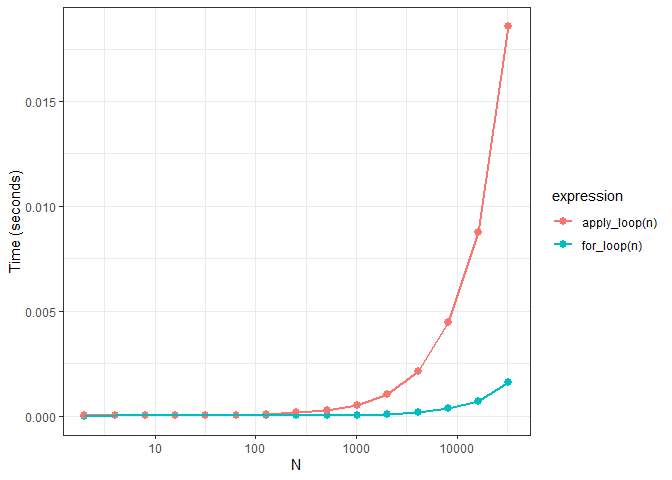

## Different looping methods

So if the loop is not slow, why looping through columns is so infuriatingly slow? Because of the way we access those columns. Every time you accessing the column of a data.frame by `df[, j]` you are accessing the whole of your data.frame and only later selecting just that column. And that’s an efficiency issue that’s going to grow non-linearly with the size of your data.frame.

The magic of using `data.table` is that you will be able to only access the actual piece of memory that contains only what you are looking for. And we do that using the `set()` function. And how does that work? Well, let’s do a simple operation of columns. We are going to simply create a `column_3` that will be the result of multiplying `column_1` and `column_2`:

You specify the column name you’re referring to by their name in a string, using the `j` parameter. And then you input the desired value in the `value` parameter. Note that the `set()` function can be more verbose and definitely less clear, but whas you lose in readibility you gain it on efficiency, so let’s measure that:

```
## Running with:
##       n
```

```
## 1     4
```

```
## 2     8
```

```
## 3    16
```

```
## 4    32
```

```
## 5    64
```

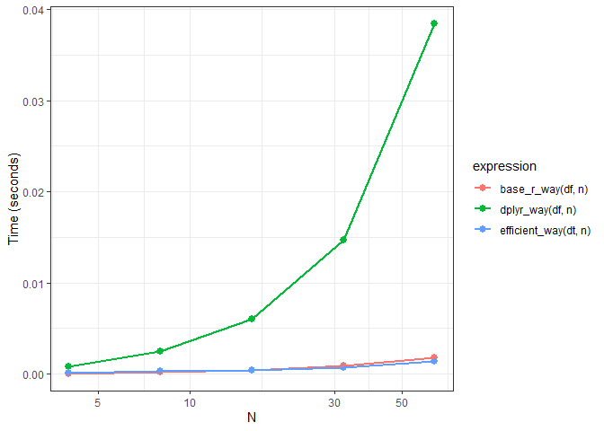

## Preventive column memory allocation

It seems that using `data.table` is going to be substantially faster than using `dplyr`, but since apparently the time required to compute using *dplyr* is blowing up, we’ll only incrase the size of the experiment using the other two, so we can compare them:

But here’s the catch: If you run this piece of code, you’ll encounter this `Internal error: DT passed to assign has not been allocated enough column slots.` Which basically means that a `data.table` object has a predefined expected number of columns that can’t be expanded using `set()`, and will throw an error once we get above that number, which is 1024. How do we solve that? It’s actually as easy as assigning those extra columns beforehand:

And now we can run the experiment with a very big number of columns and check that, indeed, using the `set()` function in a `data.table` makes looping through columns blazingly fast.

```
## Running with:
##        n
```

```
##  1     4
```

```
##  2     8
```

```
##  3    16
```

```
##  4    32
```

```
##  5    64
```

```
##  6   128
```

```
##  7   256
```

```
##  8   512
```

```
##  9  1024
```

```
## 10  2048
```

```
## 11  4096
```

```
## 12  8192
```

```
## 13 16384
```

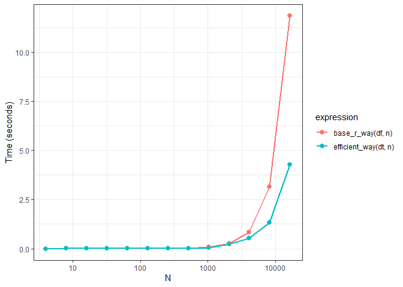